# Projet de programmation statistique avec R

Jana LAOUCHIR BEN LTAIEF Fatma

2025-01-12

Dans ce projet, on doit analyser les données des validations dans les gares d’Île-de-France en utilisant R. On va faire des résumés statistiques et créer des graphiques pour mieux comprendre les données, tout en intégrant un peu de programmation avancée.

1. Gestion des données On va importer la base de données “transport” dans R pour pouvoir l’analyser.

```r
transport <- read.csv2("C:/Users/fatma/OneDrive/Documents/BUT_SD_2_VCOD/R/project/transports.csv")
```

On va ensuite visualiser la base de données pour mieux comprendre sa structure et identifier les informations clés à analyser.

```r
View(transport)
```

On va déterminer le nombre de lignes que contient la base de données “transport” pour avoir une idée de sa taille

```r
nrow(transport)
```

```
## [1] 859043
```

Ensuite le nombre de colonnes.

```r
ncol(transport)
```

```
## [1] 8
```

On va lister le nom de chaque variable contenue dans la base de données “transport”

```r
colnames(transport)
```

```
## [1] "JOUR"            "CODE_STIF_TRNS"  "CODE_STIF_RES"   "CODE_STIF_ARRET"
## [5] "LIBELLE_ARRET"   "ID_ZDC"          "CATEGORIE_TITRE" "NB_VALD"
```

Comme vous pouvez le voir, il y a plusieurs variables dans la base de données, mais nous allons nous concentrer uniquement sur certaines d’entre elles, car les autres ne sont pas pertinentes pour notre analyse. Nous avons essayé de trouver une description détaillée de ces variables, mais nous n’avons pas réussi à en obtenir.

On va déterminer le nombre de valeurs manquantes dans la base de données “transport” afin de savoir si des traitements sont nécessaires avant de poursuivre l’analyse.

```r
sum(is.na(transport))
```

```
## [1] 1810
```

Regardons ensuite quelles variables contiennent des valeurs manquantes. On peut voir ici que “CODE_STIF_RES” et “CODE_STIF_ARRET” contiennent 905 NA. Cependant, comme ces variables ne sont pas pertinentes pour notre analyse, nous allons les laisser telles quelles.

```r
colSums(is.na(transport))
```

```
##            JOUR  CODE_STIF_TRNS   CODE_STIF_RES CODE_STIF_ARRET   LIBELLE_ARRET
##               0               0             905             905               0
##          ID_ZDC CATEGORIE_TITRE         NB_VALD
##               0               0               0
```

2. Résumé statistique pertinent pour chaque variable (minimum, maximum, moyenne, médiane et écart-type)

Nous avons réalisé un résume statistique seulement pour la variable NB_VALD car il s’agit de la seule variable quantitative:

```r
transport %>%
        summarise(min_nb_vald = min(NB_VALD),
                  max_nb_vald = max(NB_VALD),
                  moy_nb_vald = mean(NB_VALD, na.rm = T),
                  med_nb_vald = median(NB_VALD, na.rm = T),
                  sd_nb_vald  = sd(NB_VALD))
```

```
##   min_nb_vald max_nb_vald moy_nb_vald med_nb_vald sd_nb_vald
## 1           1       91398    1103.896         247   2778.769
```

La distribution des validations montre une forte asymétrie, avec une majorité de valeurs faibles (moyenne de 1 103,9 et médiane de 247), mais des valeurs extrêmes qui expliquent l’écart-type élevé de 2778,8.

3. Résumés croisées

Nous avons réalise un résumé croisé avec les variables NB_VALD et CATEGORIE_TITRE pour avoir un résumé statistique du nombre de validation par catégorie de titre de transport(minimum, maximum, moyenne, médiane et écart-type)

```r
transport %>%
  group_by(CATEGORIE_TITRE)%>%
  summarise(min_nb_vald = min(NB_VALD),
            max_nb_vald = max(NB_VALD),
            moy_nb_vald = mean(NB_VALD, na.rm = T),
            med_nb_vald = median(NB_VALD, na.rm = T),
            sd_nb_vald  = sd(NB_VALD))
```

```
## # A tibble: 7 × 6
##   CATEGORIE_TITRE     min_nb_vald max_nb_vald moy_nb_vald med_nb_vald sd_nb_vald
##   <chr>                     <int>       <int>       <dbl>       <dbl>      <dbl>
## 1 Amethyste                     1        2591       158.           92       203.
## 2 Autres titres                 1       19040      1224.          918      1324.
## 3 Contrat Solidarité…           1       22037       875.          459      1403.
## 4 Forfait Navigo                1       91398      3525.         2132      5644.
## 5 Forfaits courts               1        3853        60.3          22       130.
## 6 Imagine R                     1       57066      1430.          912      2050.
## 7 NON DEFINI                    1        7708       216.          128       348.
```

On peut voir qu’ici la distribution des validations varie considérablement selon les catégories de titre, avec des moyennes allant de 60,32 pour les “Forfaits courts” à 3525,22 pour le “Forfait Navigo”

Nous avons également regardé le nombre total de validation par catégorie de titre de transport afin de savoir quelle catégorie de titre est la plus utilisée

```r
transport %>%
  group_by(CATEGORIE_TITRE) %>%
  summarise(NB_VALD = n())
```

```
## # A tibble: 7 × 2
##   CATEGORIE_TITRE              NB_VALD
##   <chr>                          <int>
## 1 Amethyste                     131978
## 2 Autres titres                  67013
## 3 Contrat Solidarité Transport  138251
## 4 Forfait Navigo                139661
## 5 Forfaits courts               122303
## 6 Imagine R                     139010
## 7 NON DEFINI                    120827
```

On peut le constater ici que le forfait le plus validé est le Forfait Navigo, ce qui suggère que les validations sont principalement réalisées par des personnes qui utilisent fréquemment les transports, justifiant ainsi la souscription à un Forfait Navigo.

Nous avons réalise un résumé croisé avec les variables NB_VALD et LIBELLE_ARRET pour avoir un résumé statistique du nombre de validation par arret(minimum, maximum, moyenne, médiane et écart-type)

```r
transport %>%
  group_by(LIBELLE_ARRET)%>%
  summarise(min_nb_vald = min(NB_VALD),
            max_nb_vald = max(NB_VALD),
            moy_nb_vald = mean(NB_VALD, na.rm = T),
            med_nb_vald = median(NB_VALD, na.rm = T),
            sd_nb_vald  = sd(NB_VALD))
```

```
## # A tibble: 773 × 6
##    LIBELLE_ARRET  min_nb_vald max_nb_vald moy_nb_vald med_nb_vald sd_nb_vald
##    <chr>                <int>       <int>       <dbl>       <dbl>      <dbl>
##  1 ABBESSES                23        4651       709.        294       660.
##  2 ABLON                    1        1296       232.         32       315.
##  3 ACHERES GRAND            1          82        11.2         9         9.78
##  4 ACHERES VILLE            1        2387       372.         66.5     551.
##  5 AEROPORT CDG1            1       11364      1442.        616.     1923.
##  6 AEROPORT CDG2            1        5593       654.        326.      852.
##  7 AIME CESAIRE             3        2195       563.        360       589.
##  8 ALESIA                  16        8404      1745.       1024.     2088.
##  9 ALEXANDR.DUMAS           4        5302      1208.        809      1368.
## 10 ALFORT-ECOLE V           4        6901      1166.        804.     1387.
## # ℹ 763 more rows
```

Nous avons également regardé le nombre total de validation par arret afin de savoir quel arret est le plus fréquenté

```r
transport %>%
  group_by(LIBELLE_ARRET) %>%
  summarise(NB_VALD = n())
```

```
## # A tibble: 773 × 2
##    LIBELLE_ARRET  NB_VALD
##    <chr>            <int>
##  1 ABBESSES          1260
##  2 ABLON             1062
##  3 ACHERES GRAND      634
##  4 ACHERES VILLE     1074
##  5 AEROPORT CDG1     1122
##  6 AEROPORT CDG2      806
##  7 AIME CESAIRE      1273
##  8 ALESIA            1274
##  9 ALEXANDR.DUMAS    1274
## 10 ALFORT-ECOLE V    1274
## # ℹ 763 more rows
```

Nous avons réalise un résumé croisé avec les variables NB_VALD et JOUR pour avoir un résumé statistique du nombre de validation par jour(minimum, maximum, moyenne, médiane et écart-type)

```r
transport %>%
  group_by(JOUR)%>%
  summarise(min_nb_vald = min(NB_VALD),
            max_nb_vald = max(NB_VALD),
            moy_nb_vald = mean(NB_VALD, na.rm = T),
            med_nb_vald = median(NB_VALD, na.rm = T),
            sd_nb_vald  = sd(NB_VALD))%>%
  slice_head(n = 20)
```

```
## # A tibble: 20 × 6
##    JOUR       min_nb_vald max_nb_vald moy_nb_vald med_nb_vald sd_nb_vald
##    <chr>            <int>       <int>       <dbl>       <dbl>      <dbl>
##  1 2024-01-01           1       18166        291.        80.5       719.
##  2 2024-01-02           1       54281        867.       208.       2188.
##  3 2024-01-03           1       64227       1010.       236.       2542.
##  4 2024-01-04           1       68882       1061.       245        2718.
##  5 2024-01-05           1       60649       1039.       252        2518.
##  6 2024-01-06           1       51248        802.       196        1918.
##  7 2024-01-07           1       29347        536.       138        1264.
##  8 2024-01-08           1       77782       1190.       263        2999.
##  9 2024-01-09           1       83598       1276.       278.       3245.
## 10 2024-01-10           1       81553       1284.       289        3195.
## 11 2024-01-11           1       81542       1327.       298        3307.
## 12 2024-01-12           1       70139       1254.       287        2940.
## 13 2024-01-13           1       50221        894.       213        2067.
## 14 2024-01-14           1       30593        576.       148        1344.
## 15 2024-01-15           1       80445       1262.       282        3142.
## 16 2024-01-16           1       86988       1358.       299        3392.
## 17 2024-01-17           1       72368       1258.       278        2972.
## 18 2024-01-18           1       69159       1258.       279        2936.
## 19 2024-01-19           1       72378       1284.       287        2975.
## 20 2024-01-20           1       51528        915.       212        2096.
```

Comme on peut le voir ici on a les 20 résumés statistiques.

4. Analyse par sous-groupe Nous avons crée une table qui contient tout les arrêts qui ont un nombre de validation (NB_VALD) supérieur à 1000 et un titre de transport(CATEGORIE_TITRE) “forfait navigo” pour savoir quelles sont les arrêts qui sont leS plus fréquentéS par des personnes ayant un titre “forfait navigo”.

```r
table_1 <- transport %>%
  filter(NB_VALD > 1000 & CATEGORIE_TITRE %in% "Forfait Navigo") %>%
  arrange(desc(NB_VALD))%>%slice_head(n = 20)
table_1
```

```
##          JOUR CODE_STIF_TRNS CODE_STIF_RES CODE_STIF_ARRET LIBELLE_ARRET ID_ZDC
## 1  2024-04-23            800           854             822  SAINT-LAZARE  71370
## 2  2024-01-30            800           854             822  SAINT-LAZARE  71370
## 3  2024-06-11            800           854             822  SAINT-LAZARE  71370
## 4  2024-06-04            800           854             822  SAINT-LAZARE  71370
## 5  2024-03-19            800           854             822  SAINT-LAZARE  71370
## 6  2024-06-25            800           854             822  SAINT-LAZARE  71370
## 7  2024-01-16            800           854             822  SAINT-LAZARE  71370
## 8  2024-03-05            800           854             822  SAINT-LAZARE  71370
## 9  2024-06-06            800           854             822  SAINT-LAZARE  71370
## 10 2024-03-26            800           854             822  SAINT-LAZARE  71370
## 11 2024-03-12            800           854             822  SAINT-LAZARE  71370
## 12 2024-06-18            800           854             822  SAINT-LAZARE  71370
## 13 2024-04-25            800           854             822  SAINT-LAZARE  71370
## 14 2024-06-20            800           854             822  SAINT-LAZARE  71370
```

[output cut: 27 more lines]

Nous avons une 2éme table qui contient toute les informations de l’arret “St cloud” qui a un nombre de validation supérieur à 1000.

```r
table_2 <- transport %>%
  filter(NB_VALD>1000 & LIBELLE_ARRET %in% "ST CLOUD")%>%
  slice_head(n = 20)
table_2
```

```
##          JOUR CODE_STIF_TRNS CODE_STIF_RES CODE_STIF_ARRET LIBELLE_ARRET ID_ZDC
## 1  2024-01-26            800           854             812      ST CLOUD  73749
## 2  2024-02-03            800           854             812      ST CLOUD  73749
## 3  2024-04-20            800           854             812      ST CLOUD  73749
## 4  2024-04-16            800           854             812      ST CLOUD  73749
## 5  2024-04-16            800           854             812      ST CLOUD  73749
## 6  2024-05-17            800           854             812      ST CLOUD  73749
## 7  2024-05-15            800           854             812      ST CLOUD  73749
## 8  2024-05-05            800           854             812      ST CLOUD  73749
## 9  2024-03-24            800           854             812      ST CLOUD  73749
## 10 2024-04-02            800           854             812      ST CLOUD  73749
## 11 2024-04-03            800           854             812      ST CLOUD  73749
## 12 2024-04-12            800           854             812      ST CLOUD  73749
## 13 2024-03-31            800           854             812      ST CLOUD  73749
## 14 2024-01-04            800           854             812      ST CLOUD  73749
```

[output cut: 27 more lines]

Nous avons crée une autre table qui contient tout les arrêts “SAINT-LAZARE” et le titre de transport “Forfait Navigo”.

```r
table_3 <- transport %>%
  filter(LIBELLE_ARRET == "SAINT-LAZARE" & CATEGORIE_TITRE %in% "Forfait Navigo")%>%
  slice_head(n = 20)
table_3
```

```
##          JOUR CODE_STIF_TRNS CODE_STIF_RES CODE_STIF_ARRET LIBELLE_ARRET ID_ZDC
## 1  2024-01-23            100           110             769  SAINT-LAZARE  71370
## 2  2024-03-05            100           110             769  SAINT-LAZARE  71370
## 3  2024-01-28            100           110             769  SAINT-LAZARE  71370
## 4  2024-02-05            100           110             769  SAINT-LAZARE  71370
## 5  2024-02-03            800           854             822  SAINT-LAZARE  71370
## 6  2024-03-07            100           110             769  SAINT-LAZARE  71370
## 7  2024-04-20            800           854             822  SAINT-LAZARE  71370
## 8  2024-04-21            100           110             769  SAINT-LAZARE  71370
## 9  2024-05-16            100           110             769  SAINT-LAZARE  71370
## 10 2024-05-13            800           854             822  SAINT-LAZARE  71370
## 11 2024-05-14            800           854             822  SAINT-LAZARE  71370
## 12 2024-05-04            100           110             769  SAINT-LAZARE  71370
## 13 2024-05-07            100           110             769  SAINT-LAZARE  71370
## 14 2024-05-10            100           110             769  SAINT-LAZARE  71370
```

[output cut: 27 more lines]

5)Visualisations graphiques Pour la partie statistique, nous allons tout d’abord regarder quels sont les 10 arrêts les plus fréquentés en regroupant les données par arrêt et en calculant le total des validations pour chacun.

```r
top_arrets <- transport %>%
              group_by(LIBELLE_ARRET) %>%
              summarise(Total_Vald = sum(NB_VALD)) %>%
              arrange(desc(Total_Vald)) %>%
              slice_head(n = 10)
top_arrets
```

```
## # A tibble: 10 × 2
##    LIBELLE_ARRET Total_Vald
##    <chr>              <int>
##  1 SAINT-LAZARE    34191074
##  2 CHATELET        22050179
##  3 GARE DE LYON    19696028
##  4 LA DEFENSE      16076541
##  5 GARE DU NORD    15270456
##  6 MONTPARNASSE    14823464
##  7 GARE DE L'EST   13419660
##  8 LES HALLES       7587515
##  9 REPUBLIQUE       7421493
## 10 NATION           6237082
```

Ensuite, nous les visualiserons à l’aide d’un graphique en barres. Cette visualisation nous permet de comprendre rapidement la répartition des validations parmi les principaux arrêts et de focaliser sur ceux ayant la plus forte fréquentation.

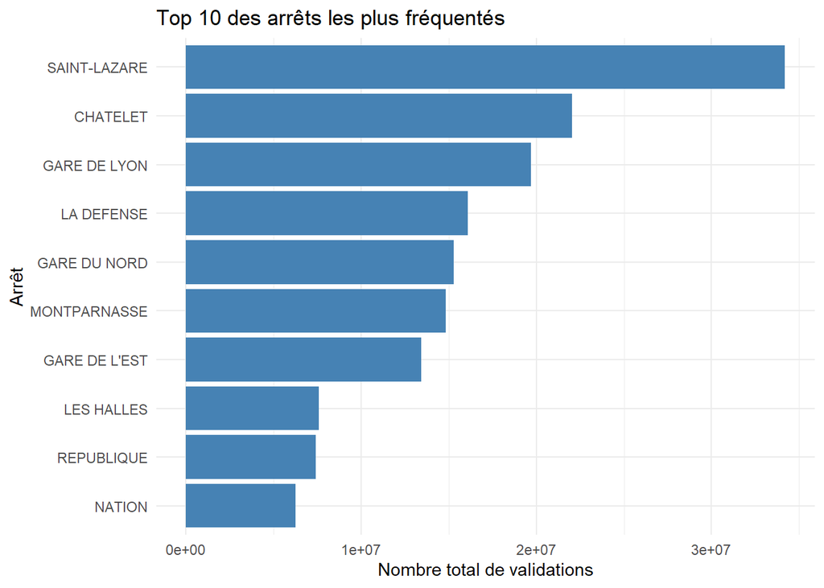

```r
ggplot(top_arrets, aes(x = reorder(LIBELLE_ARRET, Total_Vald), y = Total_Vald)) +
        geom_bar(stat = "identity", fill = "steelblue") +
        coord_flip() +
        labs(title = "Top 10 des arrêts les plus fréquentés",
             x = "Arrêt",
             y = "Nombre total de validations") +
        theme_minimal()
```

Dans ce graphique on regarde quel type de forfaits est le plus validé selon le jour de la semaine. Tout d’abord on a crée une variable jour de la semaine et puis on a cumuler les effectifs de chaque nombre de validations selon le type du forfait

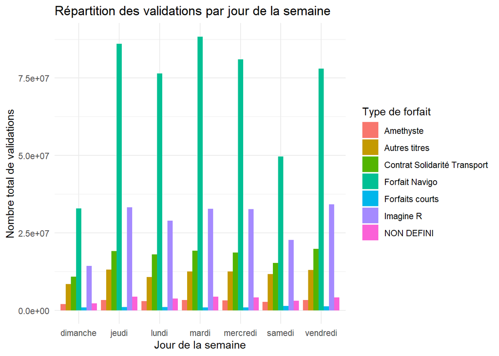

```r
transport <- transport %>%
            mutate(Jour_Semaine = weekdays(as.Date(JOUR)))

ggplot(transport, aes(x = Jour_Semaine, y = NB_VALD, fill = CATEGORIE_TITRE)) +
         geom_bar(stat = "summary", fun = "sum", position = "dodge") +
        labs(title = "Répartition des validations par jour de la semaine",
             x = "Jour de la semaine",
             y = "Nombre total de validations",
             fill = "Type de forfait") +
        theme_minimal()
```

Les validations sont dominées par le Forfait Navigo, surtout en semaine, avec des volumes dépassant 75 millions, tandis que les autres forfaits restent moins utilisés et plus stables. Le dimanche, les validations chutent globalement, mais le Forfait Navigo reste le plus utilisé malgré une forte baisse

Nous souhaitons analyser les types de forfaits utilisés lors de la journée la plus et la moins fréquentée des transports pour déterminer s’il existe une corrélation entre l’afflux de passagers et le type de forfait

```r
which.max(transport$NB_VALD)
```

```
## [1] 182011
```

```r
transport[182011,]#jour le plus frequente
```

```
##              JOUR CODE_STIF_TRNS CODE_STIF_RES CODE_STIF_ARRET LIBELLE_ARRET
## 182011 2024-04-23            800           854             822  SAINT-LAZARE
##        ID_ZDC CATEGORIE_TITRE NB_VALD Jour_Semaine
## 182011  71370  Forfait Navigo   91398        mardi
```

```r
jour_le_plus_fréquenté <- transport %>% filter(JOUR == "2024-04-23")
```

Nous cherchons à déterminer quels types de forfaits sont utilisés pendant la journée la plus fréquentée dans les transports. Pour cela, nous allons créer une visualisation sous forme de graphique à barres, ce qui nous permettra d’examiner plus en détail la distribution des différents types de forfaits employés ce jour-là.

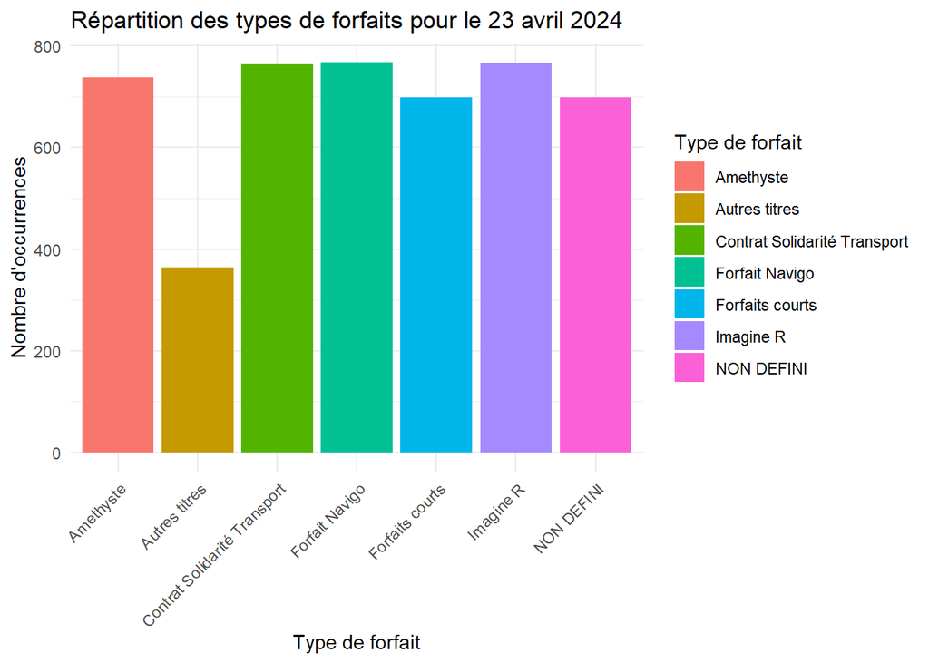

```r
ggplot(jour_le_plus_fréquenté, aes(x = CATEGORIE_TITRE, fill = CATEGORIE_TITRE)) +
  geom_bar() +
  labs(title = "Répartition des types de forfaits pour le 23 avril 2024",
       x = "Type de forfait",
       y = "Nombre d'occurrences",
       fill = "Type de forfait") +
  theme_minimal() +
  theme(axis.text.x = element_text(angle = 45, hjust = 1))
```

```r
which.min(transport$NB_VALD)
```

```
## [1] 143
```

```r
transport[143,]
```

```
##           JOUR CODE_STIF_TRNS CODE_STIF_RES CODE_STIF_ARRET   LIBELLE_ARRET
## 143 2024-01-22            800           800            1206 DUGNY COURNEUVE
##     ID_ZDC CATEGORIE_TITRE NB_VALD Jour_Semaine
## 143 426093 Forfaits courts       1        lundi
```

```r
jour_le_moins_fréquenté <- transport %>% filter(JOUR == "2024-01-22")
```

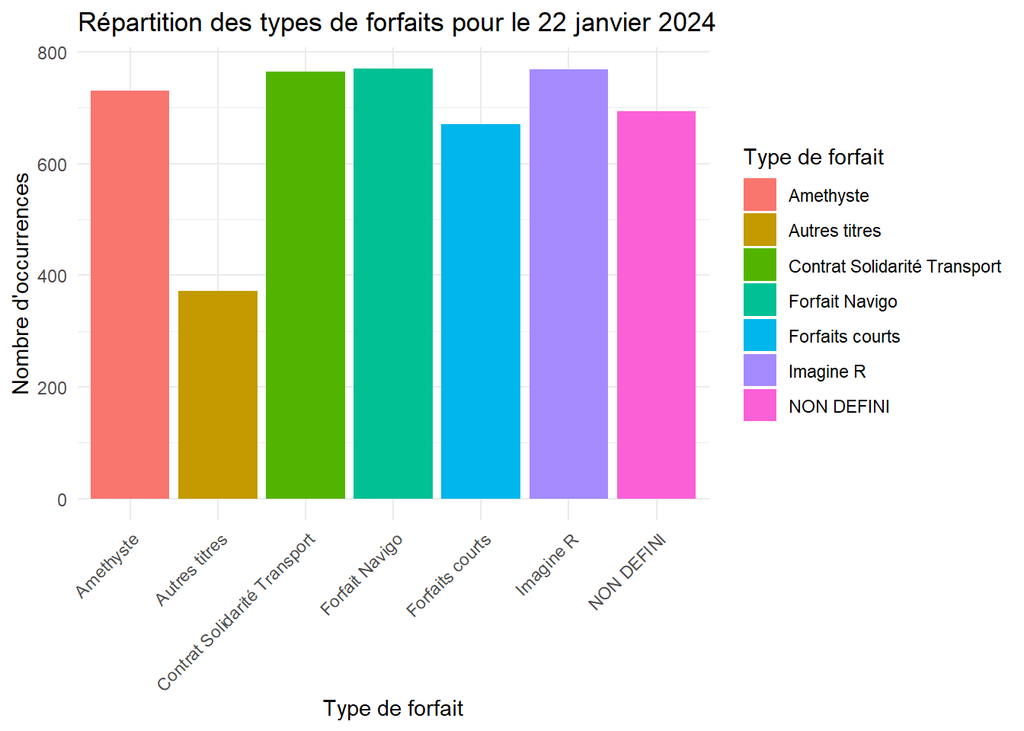

```r
ggplot(jour_le_moins_fréquenté, aes(x = CATEGORIE_TITRE, fill = CATEGORIE_TITRE)) +
  geom_bar() +
  labs(title = "Répartition des types de forfaits pour le 22 janvier 2024",
       x = "Type de forfait",
       y = "Nombre d'occurrences",
       fill = "Type de forfait") +
  theme_minimal() +
  theme(axis.text.x = element_text(angle = 45, hjust = 1))
```

Dans le cadre de notre projet, nous avons réalisé une courbe représentant l’évolution quotidienne du nombre total de validations dans les transports en commun sur une période allant de janvier à juillet 2024. Cette visualisation permet d’identifier des tendances et des comportements d’utilisation des transports en fonction des jours.

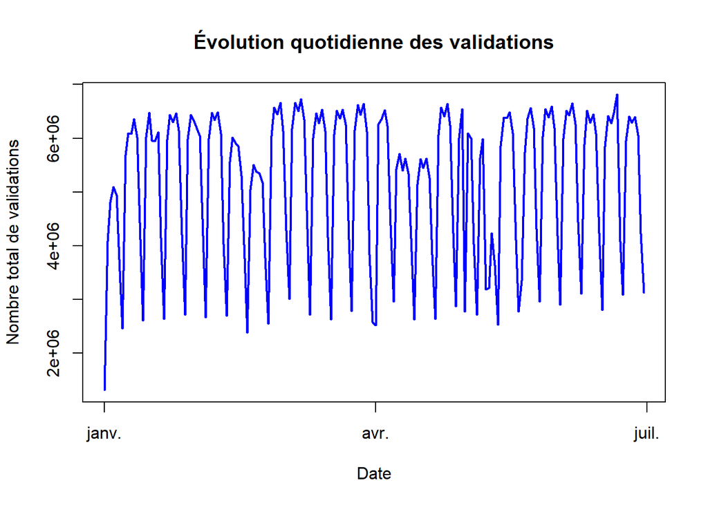

```r
transport$JOUR <- as.Date(transport$JOUR, format = "%Y-%m-%d")
validations_par_jour <- aggregate(NB_VALD ~ JOUR, data = transport, sum)
plot(validations_par_jour$JOUR, validations_par_jour$NB_VALD,
           type = "l",
           main = "Évolution quotidienne des validations",
           xlab = "Date",
           ylab = "Nombre total de validations",
           col = "blue",
           lwd = 2)
```

Cette courbe montre l’évolution quotidienne des validations dans les transports en commun entre janvier 2024 et juillet 2024, avec une alternance régulière de pics correspondant aux jours de semaine et de creux les week-ends. On observe également des baisses ponctuelles plus marquées, probablement dues à des jours fériés, des vacances scolaires ou d’autres événements spécifiques impactant la fréquentation.

6)Programmation avancée Sur cette carte, chaque arrêt sera représenté par un cercle dont la taille et la couleur, proportionnelles au nombre de validations, permettront d’identifier facilement les zones de forte fréquentation.

Nous allons créer tout d’abord un tableau regroupant les dix arrêts les plus fréquentés avec leurs coordonnées et leur nombre de validations, afin de les visualiser sur une carte interactive.

```r
arrêts_data <- data.frame(
        LIBELLE_ARRET = c("SAINT-LAZARE", "CHATELET", "GARE DE LYON", "LA DEFENSE", "GARE DU NORD",
                          "MONTPARNASSE", "GARE DE L'EST", "LES HALLES", "REPUBLIQUE", "NATION"),
        LAT = c(48.875, 48.858, 48.844, 48.892, 48.880, 48.840, 48.876, 48.861, 48.866, 48.849),
        LON = c(2.325, 2.346, 2.373, 2.236, 2.357, 2.320, 2.358, 2.346, 2.369, 2.392),
        NB_VALD = c(34191074, 22050179, 19696028, 16076541, 15270456, 14823464, 13419660, 7587515, 7421493, 6237082)
      )
```

Ce code crée une carte interactive avec les arrêts de transport représentés par des cercles proportionnels au nombre de validations, dont la couleur et la taille varient en fonction de leur fréquentation. Une légende est ajoutée pour expliquer le dégradé de couleurs, et un popup affiche le nom de chaque arrêt ainsi que le nombre de validations lorsqu’on clique sur un cercle.

```r
leaflet(arrêts_data) %>%
        addTiles() %>%
        addCircles(
          lng = ~LON, lat = ~LAT, radius = ~NB_VALD / 100000,
          color = ~colorNumeric(palette = "Blues", domain =         arrêts_data$NB_VALD)(NB_VALD),
          stroke = FALSE, fillOpacity = 0.7,
          popup = ~paste(LIBELLE_ARRET, "<br>Nombre de validations: ", NB_VALD)
        ) %>%
        addLegend(
          position = "bottomright",
          pal = colorNumeric(palette = "Blues", domain = arrêts_data$NB_VALD),
          values = arrêts_data$NB_VALD,
          title = "Nombre de validations",
          opacity = 1
        )
```

[interactive chart not shown]